```python
import warnings
warnings.filterwarnings('ignore')
```

# 8. Data exploration & Insights

# 8.1 Goals & Objective

- The goal here is to understand through steps, means to explore and develop intuition about unknown data
- While data may come from different sources they have several characteristics in common in terms of the data type and the quality of data
- Here we shall take a small data set and use strategies that shall generalize well for unkown data
- Usually this analysis is described a Exploratory Data Analysis (EDA) but as a business manager often you can use some of these techniques purely from a context of causal relationships and exploring cause-effect relationship

## 8.1.1 Variable Categories

[figure not shown]

More on [Ratio versus Interval](https://www.questionpro.com/blog/ratio-scale-vs-interval-scale/#:~:text=Interval%20scales%20hold%20no%20true,but%20never%20fall%20below%20it.)

Overall on [scales](https://www.questionpro.com/blog/nominal-ordinal-interval-ratio/#:~:text=Nominal%20scale%20is%20a%20naming,each%20of%20its%20variable%20options.) and [here](https://byjus.com/maths/scales-of-measurement/)

## 8.1.2 Analysis by Variable Category

[figure not shown]

## 8.1.3 Introducing the Analytics Scenario

**Data Description:**

- I found the reference to this data set [here](http://jse.amstat.org/v19n3/decock.pdf). Ames is a small city in the state of Iowa in the United States. It’s home to Iowa State University, which is the largest university in the state.
- The Ames housing dataset examines features of houses sold in Ames during the 2006–10 timeframe in and attempt to **predict sale price** of houses based on their features
- Usually used a academic data set to build a regression model to predict the sale prices of the houses

[figure not shown]

*Domain: Real Estate*

**Context:** [zillow.com](http://www.zillow.com/) ran a competition in [kaggle](https://www.kaggle.com/c/zillow-prize-1) for a $1.2 Million prize to accurately predict price of real estate properties. In fact Zilow Reseach provides housing data for [download](https://www.zillow.com/research/data/) for citizen data scientists.

The Ames data is in the same thread and very common in academic circles to explain regression and non-linearity of features.

In this class we shall use the data set to explore data and understand better how predictor variables drive/ impact target/ dependent variable; and how predictor may be related to each other.

| Variable Category | Description | Column Name |
| --- | --- | --- |
| Nominal | Categorical, Mutually exclusive, but not ordered, categories | MS Zoning, Street Type, Land Contour, Lot Config, **Neighborhood** |
| Ordinal | Categorical, order matters but not the difference between values | Utilities, Land Slope, Overall Qual,Overall Cond |
| Interval | Difference between two values is meaningful | Garage Yr Blt, Yr Sold |
| Ratio | All the properties of an interval variable, but also has a clear definition of 0.0 | Lot Frontage, Lot Area |

```python
# standard libraries
import numpy as np
import pandas as pd
import seaborn as sns
import matplotlib.pyplot as plt
# Plotting pretty figures and avoid blurry images
%config InlineBackend.figure_format = 'retina'
# Larger scale for plots in notebooks
sns.set_context('notebook')
```

```python
df = pd.read_csv('https://raw.githubusercontent.com/hjhuney/Data/master/AmesHousing/train.csv', index_col=0)
```

```python
df.isnull().sum()[df.isnull().sum()>0]
```

```
LotFrontage      259
Alley           1369
MasVnrType         8
MasVnrArea         8
BsmtQual          37
BsmtCond          37
BsmtExposure      38
BsmtFinType1      37
BsmtFinType2      38
Electrical         1
FireplaceQu      690
GarageType        81
GarageYrBlt       81
GarageFinish      81
GarageQual        81
GarageCond        81
PoolQC          1453
Fence           1179
MiscFeature     1406
dtype: int64
```

```python
df.fillna(df.median(),inplace=True)
```

[Data Dictionary](http://jse.amstat.org/v19n3/decock/DataDocumentation.txt) is very detailed and can be found here. Please make sure to familiarize

# 8.2 High Level Data Review

## 8.2.1 Column Description

This is a tabular data. We add the column names based on the data definition

```python
df.shape
```

```
(1460, 80)
```

```python
df.columns[df.dtypes=='object']
```

```
Index(['MSZoning', 'Street', 'Alley', 'LotShape', 'LandContour', 'Utilities',
       'LotConfig', 'LandSlope', 'Neighborhood', 'Condition1', 'Condition2',
       'BldgType', 'HouseStyle', 'RoofStyle', 'RoofMatl', 'Exterior1st',
       'Exterior2nd', 'MasVnrType', 'ExterQual', 'ExterCond', 'Foundation',
       'BsmtQual', 'BsmtCond', 'BsmtExposure', 'BsmtFinType1', 'BsmtFinType2',
       'Heating', 'HeatingQC', 'CentralAir', 'Electrical', 'KitchenQual',
       'Functional', 'FireplaceQu', 'GarageType', 'GarageFinish', 'GarageQual',
       'GarageCond', 'PavedDrive', 'PoolQC', 'Fence', 'MiscFeature',
       'SaleType', 'SaleCondition'],
      dtype='object')
```

```python
df.columns[df.dtypes=='int']
```

```
Index(['MSSubClass', 'LotArea', 'OverallQual', 'OverallCond', 'YearBuilt',
       'YearRemodAdd', 'BsmtFinSF1', 'BsmtFinSF2', 'BsmtUnfSF', 'TotalBsmtSF',
       '1stFlrSF', '2ndFlrSF', 'LowQualFinSF', 'GrLivArea', 'BsmtFullBath',
       'BsmtHalfBath', 'FullBath', 'HalfBath', 'BedroomAbvGr', 'KitchenAbvGr',
       'TotRmsAbvGrd', 'Fireplaces', 'GarageCars', 'GarageArea', 'WoodDeckSF',
       'OpenPorchSF', 'EnclosedPorch', '3SsnPorch', 'ScreenPorch', 'PoolArea',
       'MiscVal', 'MoSold', 'YrSold', 'SalePrice'],
      dtype='object')
```

```python
df.columns[df.dtypes=='float']
```

```
Index(['LotFrontage', 'MasVnrArea', 'GarageYrBlt'], dtype='object')
```

```python
df.loc[:,df.columns[df.dtypes!='object']].describe().T
```

|  | count | mean | std | min | 25% | 50% | 75% | max |
| --- | --- | --- | --- | --- | --- | --- | --- | --- |
| MSSubClass | 1460.0 | 56.897260 | 42.300571 | 20.0 | 20.00 | 50.0 | 70.00 | 190.0 |
| LotFrontage | 1460.0 | 69.863699 | 22.027677 | 21.0 | 60.00 | 69.0 | 79.00 | 313.0 |
| LotArea | 1460.0 | 10516.828082 | 9981.264932 | 1300.0 | 7553.50 | 9478.5 | 11601.50 | 215245.0 |
| OverallQual | 1460.0 | 6.099315 | 1.382997 | 1.0 | 5.00 | 6.0 | 7.00 | 10.0 |
| OverallCond | 1460.0 | 5.575342 | 1.112799 | 1.0 | 5.00 | 5.0 | 6.00 | 9.0 |
| YearBuilt | 1460.0 | 1971.267808 | 30.202904 | 1872.0 | 1954.00 | 1973.0 | 2000.00 | 2010.0 |
| YearRemodAdd | 1460.0 | 1984.865753 | 20.645407 | 1950.0 | 1967.00 | 1994.0 | 2004.00 | 2010.0 |
| MasVnrArea | 1460.0 | 103.117123 | 180.731373 | 0.0 | 0.00 | 0.0 | 164.25 | 1600.0 |
| BsmtFinSF1 | 1460.0 | 443.639726 | 456.098091 | 0.0 | 0.00 | 383.5 | 712.25 | 5644.0 |
| BsmtFinSF2 | 1460.0 | 46.549315 | 161.319273 | 0.0 | 0.00 | 0.0 | 0.00 | 1474.0 |
| BsmtUnfSF | 1460.0 | 567.240411 | 441.866955 | 0.0 | 223.00 | 477.5 | 808.00 | 2336.0 |
| TotalBsmtSF | 1460.0 | 1057.429452 | 438.705324 | 0.0 | 795.75 | 991.5 | 1298.25 | 6110.0 |
| 1stFlrSF | 1460.0 | 1162.626712 | 386.587738 | 334.0 | 882.00 | 1087.0 | 1391.25 | 4692.0 |
| 2ndFlrSF | 1460.0 | 346.992466 | 436.528436 | 0.0 | 0.00 | 0.0 | 728.00 | 2065.0 |
| LowQualFinSF | 1460.0 | 5.844521 | 48.623081 | 0.0 | 0.00 | 0.0 | 0.00 | 572.0 |
| GrLivArea | 1460.0 | 1515.463699 | 525.480383 | 334.0 | 1129.50 | 1464.0 | 1776.75 | 5642.0 |
| BsmtFullBath | 1460.0 | 0.425342 | 0.518911 | 0.0 | 0.00 | 0.0 | 1.00 | 3.0 |
| BsmtHalfBath | 1460.0 | 0.057534 | 0.238753 | 0.0 | 0.00 | 0.0 | 0.00 | 2.0 |
| FullBath | 1460.0 | 1.565068 | 0.550916 | 0.0 | 1.00 | 2.0 | 2.00 | 3.0 |
| HalfBath | 1460.0 | 0.382877 | 0.502885 | 0.0 | 0.00 | 0.0 | 1.00 | 2.0 |
| BedroomAbvGr | 1460.0 | 2.866438 | 0.815778 | 0.0 | 2.00 | 3.0 | 3.00 | 8.0 |
| KitchenAbvGr | 1460.0 | 1.046575 | 0.220338 | 0.0 | 1.00 | 1.0 | 1.00 | 3.0 |
| TotRmsAbvGrd | 1460.0 | 6.517808 | 1.625393 | 2.0 | 5.00 | 6.0 | 7.00 | 14.0 |
| Fireplaces | 1460.0 | 0.613014 | 0.644666 | 0.0 | 0.00 | 1.0 | 1.00 | 3.0 |
| GarageYrBlt | 1460.0 | 1978.589041 | 23.997022 | 1900.0 | 1962.00 | 1980.0 | 2001.00 | 2010.0 |
| GarageCars | 1460.0 | 1.767123 | 0.747315 | 0.0 | 1.00 | 2.0 | 2.00 | 4.0 |
| GarageArea | 1460.0 | 472.980137 | 213.804841 | 0.0 | 334.50 | 480.0 | 576.00 | 1418.0 |
| WoodDeckSF | 1460.0 | 94.244521 | 125.338794 | 0.0 | 0.00 | 0.0 | 168.00 | 857.0 |
| OpenPorchSF | 1460.0 | 46.660274 | 66.256028 | 0.0 | 0.00 | 25.0 | 68.00 | 547.0 |
| EnclosedPorch | 1460.0 | 21.954110 | 61.119149 | 0.0 | 0.00 | 0.0 | 0.00 | 552.0 |
| 3SsnPorch | 1460.0 | 3.409589 | 29.317331 | 0.0 | 0.00 | 0.0 | 0.00 | 508.0 |
| ScreenPorch | 1460.0 | 15.060959 | 55.757415 | 0.0 | 0.00 | 0.0 | 0.00 | 480.0 |
| PoolArea | 1460.0 | 2.758904 | 40.177307 | 0.0 | 0.00 | 0.0 | 0.00 | 738.0 |
| MiscVal | 1460.0 | 43.489041 | 496.123024 | 0.0 | 0.00 | 0.0 | 0.00 | 15500.0 |
| MoSold | 1460.0 | 6.321918 | 2.703626 | 1.0 | 5.00 | 6.0 | 8.00 | 12.0 |
| YrSold | 1460.0 | 2007.815753 | 1.328095 | 2006.0 | 2007.00 | 2008.0 | 2009.00 | 2010.0 |
| SalePrice | 1460.0 | 180921.195890 | 79442.502883 | 34900.0 | 129975.00 | 163000.0 | 214000.00 | 755000.0 |

```python
df.loc[:,df.columns[df.dtypes=='object']].describe().T
```

|  | count | unique | top | freq |
| --- | --- | --- | --- | --- |
| MSZoning | 1460 | 5 | RL | 1151 |
| Street | 1460 | 2 | Pave | 1454 |
| Alley | 91 | 2 | Grvl | 50 |
| LotShape | 1460 | 4 | Reg | 925 |
| LandContour | 1460 | 4 | Lvl | 1311 |
| Utilities | 1460 | 2 | AllPub | 1459 |
| LotConfig | 1460 | 5 | Inside | 1052 |
| LandSlope | 1460 | 3 | Gtl | 1382 |
| Neighborhood | 1460 | 25 | NAmes | 225 |
| Condition1 | 1460 | 9 | Norm | 1260 |
| Condition2 | 1460 | 8 | Norm | 1445 |
| BldgType | 1460 | 5 | 1Fam | 1220 |
| HouseStyle | 1460 | 8 | 1Story | 726 |
| RoofStyle | 1460 | 6 | Gable | 1141 |
| RoofMatl | 1460 | 8 | CompShg | 1434 |
| Exterior1st | 1460 | 15 | VinylSd | 515 |
| Exterior2nd | 1460 | 16 | VinylSd | 504 |
| MasVnrType | 1452 | 4 | None | 864 |
| ExterQual | 1460 | 4 | TA | 906 |
| ExterCond | 1460 | 5 | TA | 1282 |
| Foundation | 1460 | 6 | PConc | 647 |
| BsmtQual | 1423 | 4 | TA | 649 |
| BsmtCond | 1423 | 4 | TA | 1311 |
| BsmtExposure | 1422 | 4 | No | 953 |
| BsmtFinType1 | 1423 | 6 | Unf | 430 |
| BsmtFinType2 | 1422 | 6 | Unf | 1256 |
| Heating | 1460 | 6 | GasA | 1428 |
| HeatingQC | 1460 | 5 | Ex | 741 |
| CentralAir | 1460 | 2 | Y | 1365 |
| Electrical | 1459 | 5 | SBrkr | 1334 |
| KitchenQual | 1460 | 4 | TA | 735 |
| Functional | 1460 | 7 | Typ | 1360 |
| FireplaceQu | 770 | 5 | Gd | 380 |
| GarageType | 1379 | 6 | Attchd | 870 |
| GarageFinish | 1379 | 3 | Unf | 605 |
| GarageQual | 1379 | 5 | TA | 1311 |
| GarageCond | 1379 | 5 | TA | 1326 |
| PavedDrive | 1460 | 3 | Y | 1340 |
| PoolQC | 7 | 3 | Gd | 3 |
| Fence | 281 | 4 | MnPrv | 157 |
| MiscFeature | 54 | 4 | Shed | 49 |
| SaleType | 1460 | 9 | WD | 1267 |
| SaleCondition | 1460 | 6 | Normal | 1198 |

# 8.3 Target Variable

- **Variable Name:** SalePrice
- **Variable Category:** Ratio [$0 is the same as GBP 0]
- **Analysis Type:** Histogram, Frequencies, mean/median/mode/std., Boxplots

## 8.3.1 Plots & Statistics

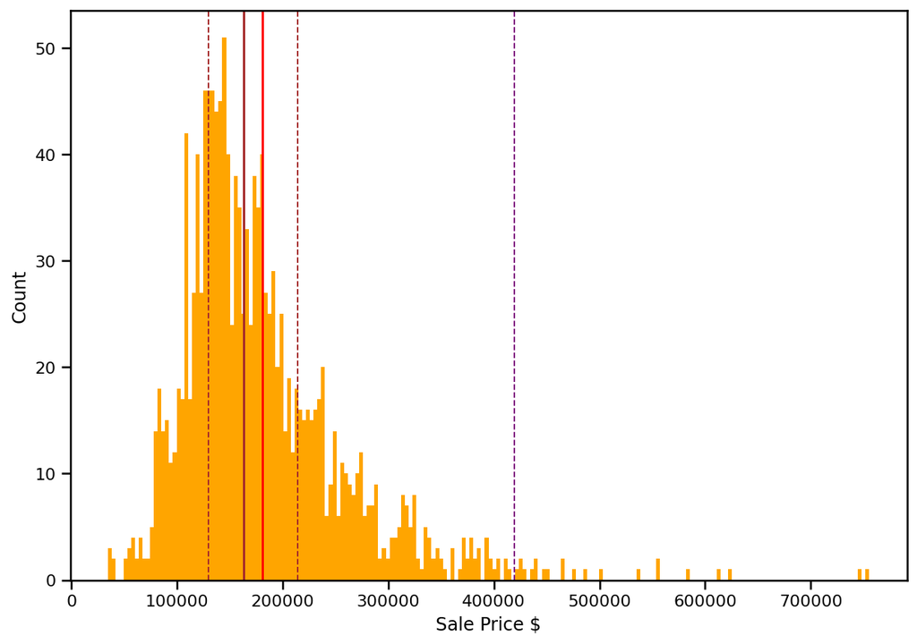

|  | 0 | 1 | 2 | 3 | 4 | 5 | 6 | 7 |
| --- | --- | --- | --- | --- | --- | --- | --- | --- |
| index | count | mean | std | min | 25% | 50% | 75% | max |
| SalePrice | 1460 | 180921 | 79442.5 | 34900 | 129975 | 163000 | 214000 | 755000 |

```python
plt.figure(figsize=(10,7))
plt.hist(df.SalePrice, color='orange', bins=200,log=False, histtype='bar')
plt.xlabel('Sale Price $')
plt.ylabel('Count')
plt.axvline(df.SalePrice.mean(), color='red', linestyle='solid', linewidth=1.5)
plt.axvline(df.SalePrice.median(), color='brown', linestyle='solid', linewidth=1.5)
plt.axvline(df.SalePrice.describe().loc['25%'], color='brown', linestyle='dashed', linewidth=1)
plt.axvline(df.SalePrice.describe().loc['75%'], color='brown', linestyle='dashed', linewidth=1)
plt.axvline(df.SalePrice.describe().loc['mean']+ 3*df.SalePrice.describe().loc['std'], color='purple', linestyle='dashed', linewidth=1)
# plt.axvline(df.SalePrice.describe().loc['mean']- 3*df.SalePrice.describe().loc['std'], color='purple', linestyle='dashed', linewidth=1)
plt.show()
df.SalePrice.describe().reset_index().T
```

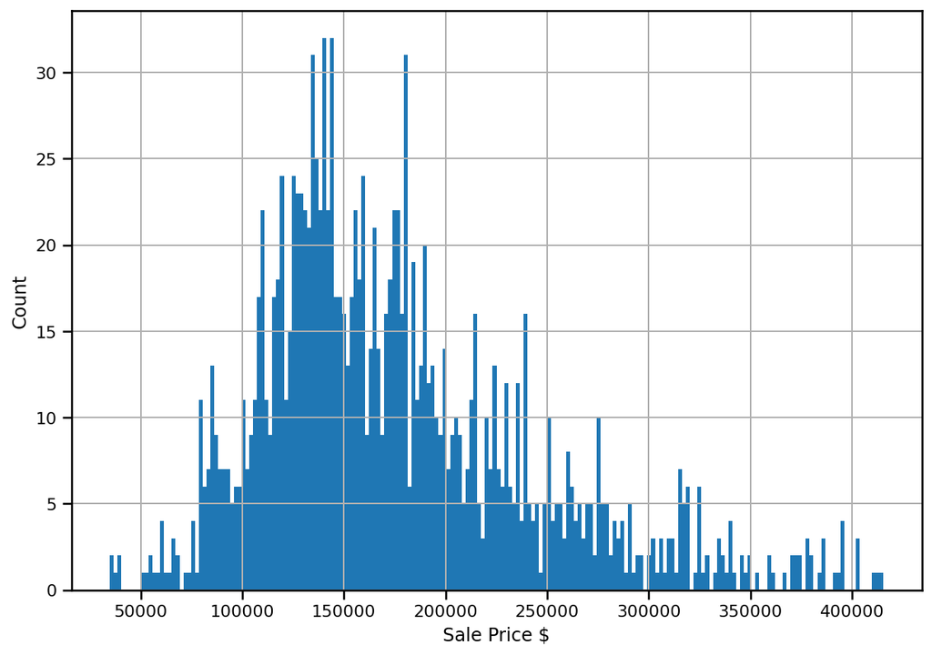

```python
plt.figure(figsize=(10,7))
# plt.hist(df.SalePrice, color='orange', bins=200,log=False, histtype='bar')
plt.xlabel('Sale Price $')
plt.ylabel('Count')
df.SalePrice[df.SalePrice < (df.SalePrice.describe().loc['mean']+ 3*df.SalePrice.describe().loc['std'])].hist(bins=200)
```

```python
df['out_flg']=df.SalePrice > df.SalePrice.describe().loc['mean']+ 3*df.SalePrice.describe().loc['std']
```

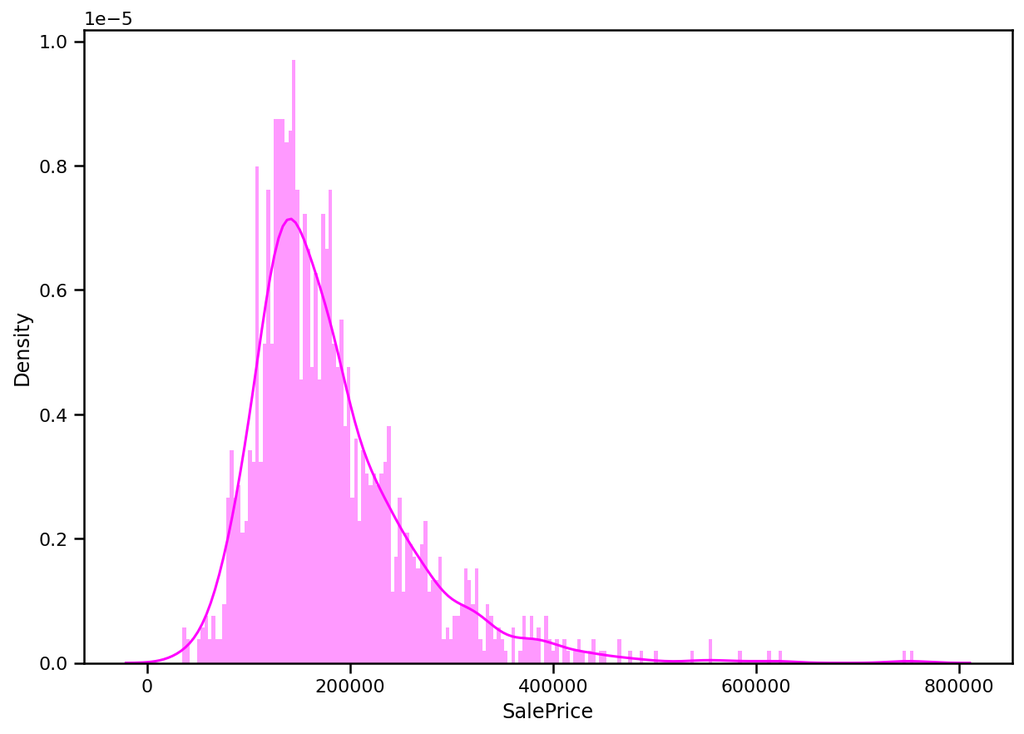

```python
a4_dims = (10, 7)
# df = mylib.load_data()
fig, ax = plt.subplots(figsize=a4_dims)
sns.distplot(df.SalePrice, bins=200, hist=True, kde=True, color= 'magenta', ax=ax)
```

```python
from scipy import stats
k2, p = stats.normaltest(df.loc[df.out_flg,'SalePrice'].values)
alpha = .05
print(p)
if p < alpha:  # null hypothesis: x comes from a normal distribution
    print("The null hypothesis can be rejected")
else:
    print("The null hypothesis cannot be rejected")
```

```
0.016859801739010225
The null hypothesis can be rejected
```

## 8.3.2 Takeaways

# 8.4 Nominal Dependent Variables

- **Variable Name:** Neighborhood, MSZoning
- **Variable Category:** Nominal
- **Analysis Type:** Bar, frequencies, Percentages More

## 8.4.1 BoxPlots

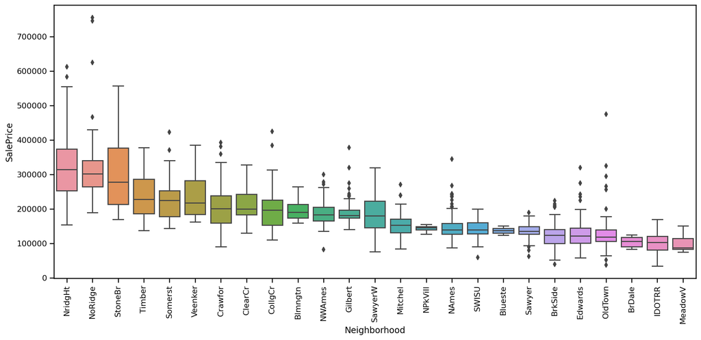

```python
sorted_nb = df.groupby(['Neighborhood'])['SalePrice'].median().sort_values(ascending= False)
sorted_nb
#dimension of the plot
a4_dims = (16, 7)
# # df = mylib.load_data()
# assign the height and width
# how to assign the dimension on a plot axis
fig, ax1 = plt.subplots(figsize=a4_dims)
ax1.set_xticklabels(ax.get_xticklabels(),rotation=90)
# , order=list(sorted_nb.index),ax=ax
### Focus on this!!!
### ax=ax is assigning the figure to a axis
sns.boxplot(x=df['Neighborhood'], y=df['SalePrice'], order=list(sorted_nb.index), ax=ax1)
```

[figure not shown]

```python
sns.boxplot()
```

## 8.4.2 Boxplot Takeaways

- We can see that in the cheapest neighborhoods houses sell for a median price of around `$100,000`, and in the most expensive neighborhoods houses sell for around $300,000.
- We can also see that for some neighborhoods, dispersion between the prices is very low, meaning that all the prices are close to each other.
- In the most expensive neighborhood `NridgHt`, however, we see a large box — there is large dispersion in the distribution of prices.

## 8.4.3 Violin Plot

- Violin plots are similar to box plots, except that they also show the probability density of the data at different values, usually smoothed by a kernel density estimator.
- Easy to spot multimodel disributions

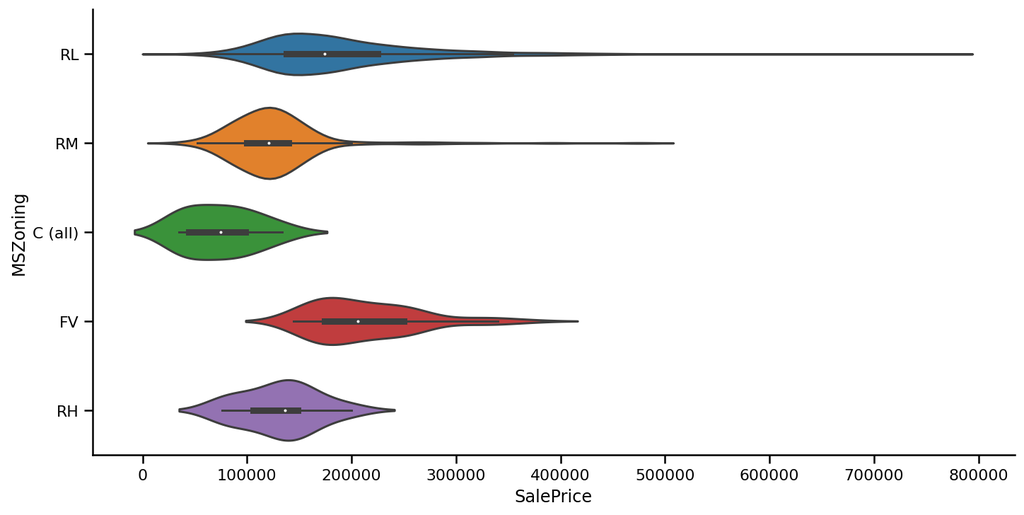

```python
sns.catplot(y="MSZoning", x="SalePrice", kind="violin", data=df, height=5, aspect=2, orient='h')
```

## 8.4.4 Violin Plot Takeaways

- `MSZoning` has significant impact on variability of sale price
- C hass the lowest mean; RL & FV has the highest mean
- RL shows a significant long tail leading to a hypothesis that higher SalePrices indeed has something to do with it

# 8.5 Ordinal Dependent Variables

- **Variable Name:** Utilities, Overall Qual, Overall Cond
- **Variable Category:** Ordinal
- **Analysis Type:** Bar, Box Plot, Stem & Leaf

## 8.5.1 Ordered Boxplot

```python
df.OverallCond.unique()
```

```
array([5, 8, 6, 7, 4, 2, 3, 9, 1])
```

```python
#util_map= {'AllPub':5,'NoSewr':4,'NoSeWa':3,'ELO':2}
#df['util_ord']= df.Utilities.map(util_map).fillna(1)
df.OverallQual= df.OverallQual.astype(int)
df.OverallCond= df.OverallCond.astype(int)
oqc_order= np.flip(np.sort(df.OverallQual.unique(), axis=0))
```

```python
np.flip(np.sort(df.OverallQual.unique(), axis=0))
```

```
array([10,  9,  8,  7,  6,  5,  4,  3,  2,  1])
```

```python
oqc_order
```

```
array([10,  9,  8,  7,  6,  5,  4,  3,  2,  1])
```

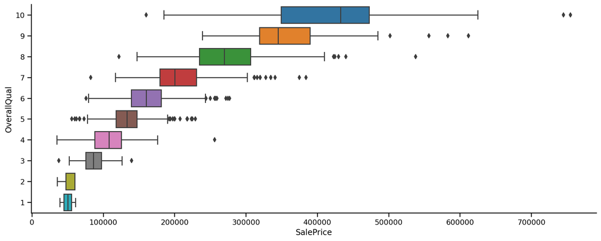

```python
sns.catplot(y="OverallQual", x="SalePrice", kind="box", data=df, height=5, aspect=2.5, orient='h',order= oqc_order)
```

## 8.5.2 Ordered Boxplot Takeaway

- As expected the mean `SalePrice` increases as quality improves; the relationship actually looks nonlinear
- At lower quality properties have lower variability of prices
- As quality improves it's clear that other factors play important role in explaining quality of the properties

## 8.5.3 Ordered Barplot

- The height of each bar represents the mean value in each category.
- Black lines at the top of each bar represent 95% confidence intervals for the mean which can be thought of as the uncertainty in our data.
- Simply put, the tips of each line are the interval where you would expect the real mean `SalePrice` in each category

```python
hqC_cat= ['Po', 'Fa', 'TA','Gd', 'Ex']
```

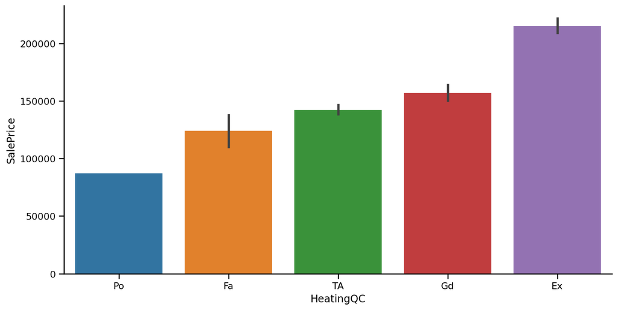

```python
sns.catplot(x='HeatingQC', y='SalePrice', data=df, kind='bar',order=hqC_cat, height=5, aspect=2)
```

## 8.5.4 Ordered Barplot Takeaways

# 8.6 Interval/ Ratio Dependent Variables

- **Variable Name:** 1stFlrSF, MasVnrArea,LotArea, YearBuilt
- **Variable Category:** First 3 Ratio; Last 1 Interval
- **Analysis Type:** Bar, frequencies, mean/median/mode/std, scatter

```python
cols= ['1stFlrSF','MasVnrArea','LotArea','YearBuilt']
```

## 8.6.1 Histogram

[output not shown]

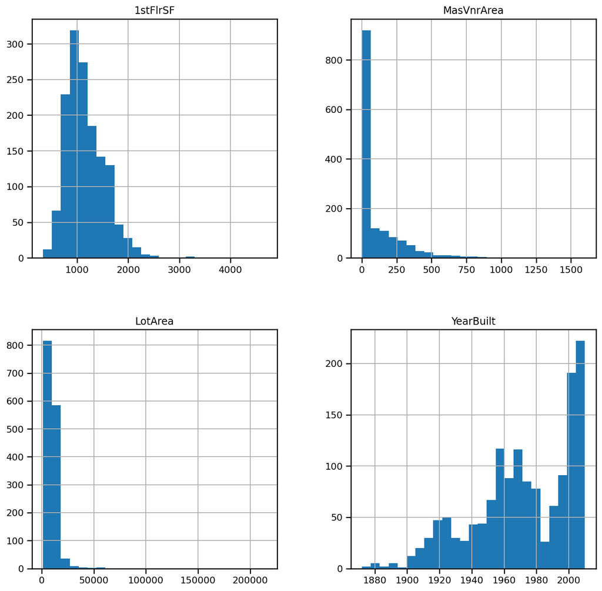

```python
df.loc[:,cols].hist(bins=25, figsize=(12, 12), layout=(2, 2))
```

## 8.6.2 Scatterplots

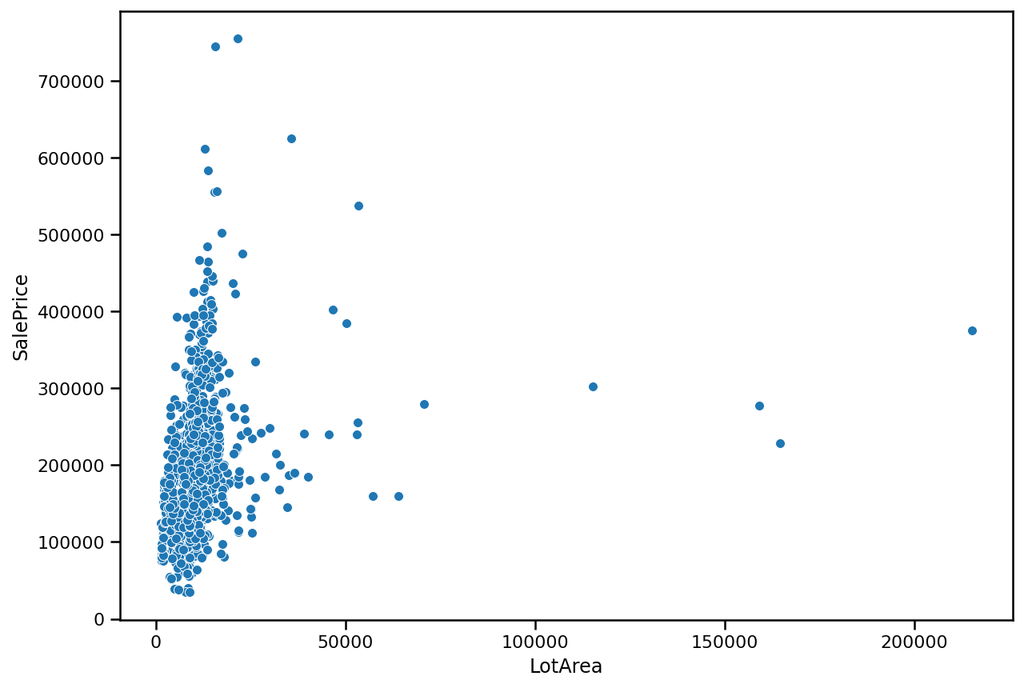

```python
a4_dims = (10, 7)
fig, ax = plt.subplots(figsize=a4_dims)
sns.scatterplot(x='LotArea', y='SalePrice', data=df,ax=ax )
# sns.scatterplot(x='LotArea', y='SalePrice', data=df.loc[df.LotArea < 50000,:],ax=ax )
```

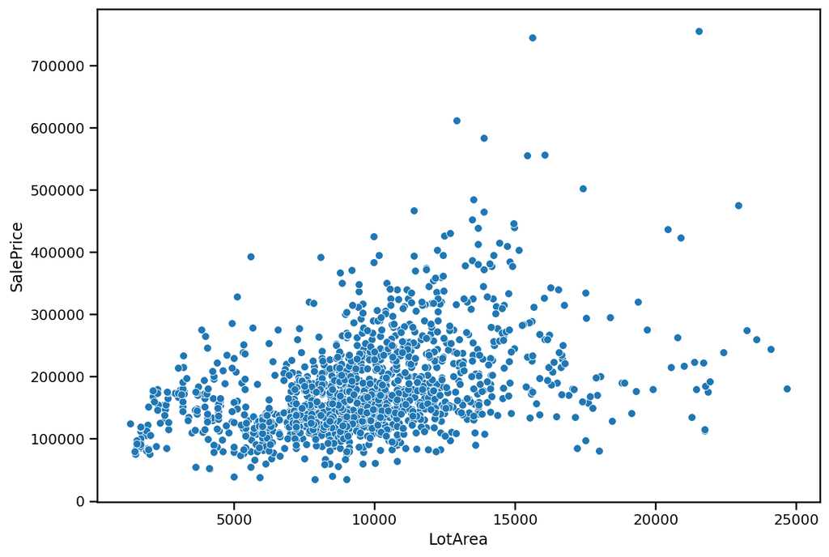

```python
a4_dims = (10, 7)
fig, ax = plt.subplots(figsize=a4_dims)
# sns.scatterplot(x='LotArea', y='SalePrice', data=df,ax=ax )
sns.scatterplot(x='LotArea', y='SalePrice', data=df.loc[df.LotArea < 25000,:],ax=ax )
```

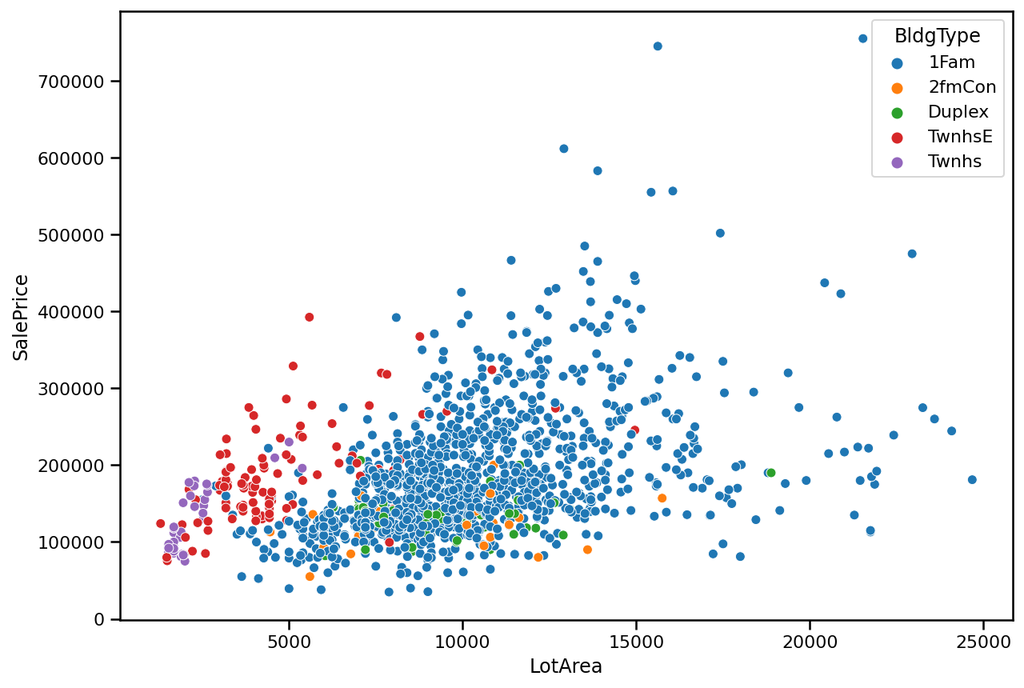

```python
a4_dims = (10, 7)
fig, ax = plt.subplots(figsize=a4_dims)
# sns.scatterplot(x='LotArea', y='SalePrice', data=df,ax=ax )
sns.scatterplot(x='LotArea', y='SalePrice', data=df.loc[df.LotArea < 25000,:],ax=ax, hue='BldgType' )
```

## 8.6.3 Marginal Plots

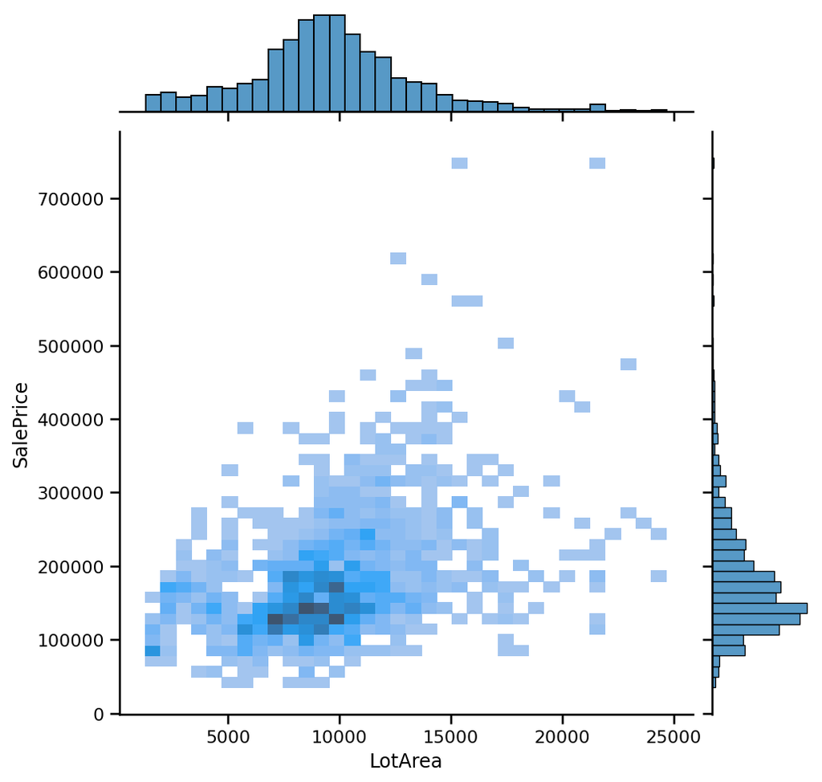

```python
sns.jointplot(x="LotArea", y="SalePrice",kind='hist', data=df.loc[df.LotArea < 25000,:], ax=ax, height=7)
```

## 8.6.4 Marginal Plots with hues

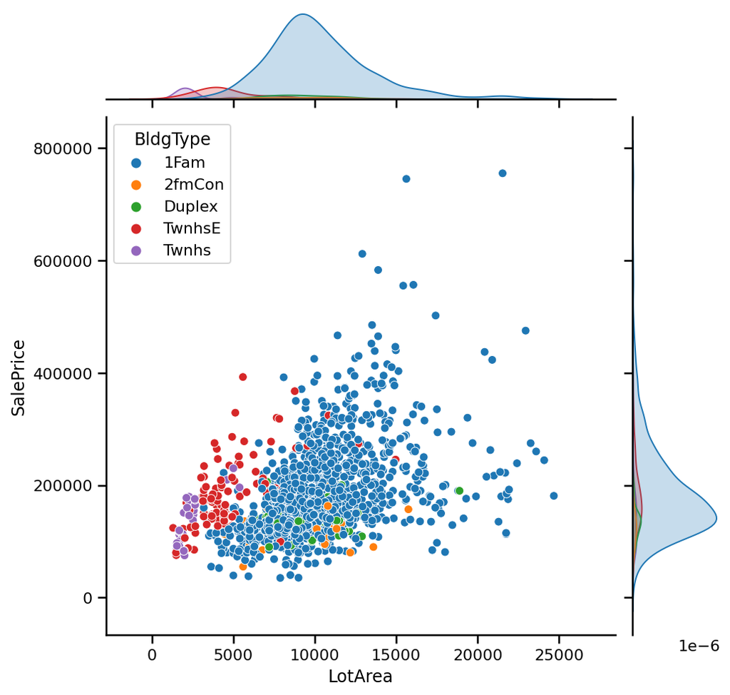

```python
sns.jointplot(data=df.loc[df.LotArea < 25000,:], x="LotArea", y="SalePrice", hue="BldgType", height=7, kind='scatter')
```